# *pitmastr*: a standardized workflow for working with PIT tag data

# 1 Getting started with *pitmastr*

This document serves as a step-by-step guide by Kailing et al for storing and working with PIT tag data using ‘pitmastr’ package.

# 2 Load ‘pitmastr’ package

```r
# through mkailing git repository
# devtools::install_github(mkailing/pitmastr)

# or if CRAN hosted
# library(pitmastr)
```

# 3 Data management

## 3.1 File storage

The way detections on the reader are stored can vary depending on the model type and programmed settings. The folder structure we recommend accommodates most file types output by the readers *See below for caveat regarding .accdb.

- Data downloaded as .log files will store detections by date in a single file.
- Newer systems allow for the export of multiple dates worth of detections into a single .txt or xlsx file.

*pitmastr* was created with this in mind and, by storing as recommended, users can simultaneously assemble all detections from the various filetypes.

**Users with detections stored as .accdb files are encouraged to export the table from MS Access as a .xlsx to be compatible with master file assembly through ‘workhorse’*.

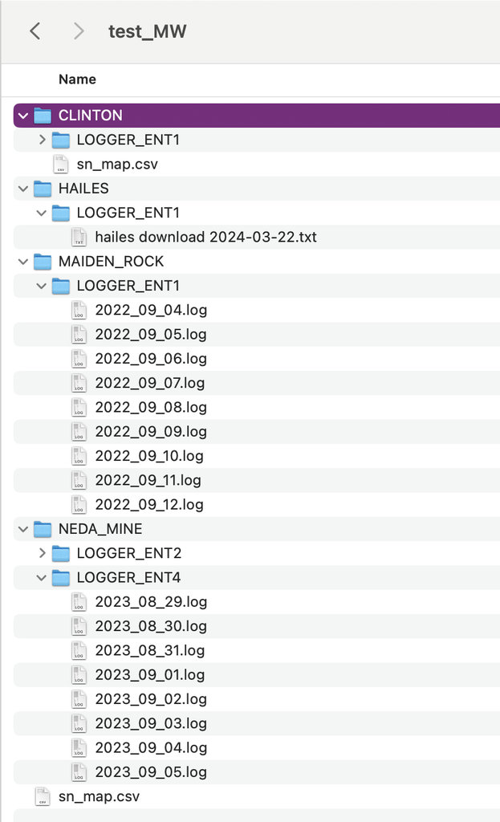

[In the above example, there exists multiple readers at a single site that need to remain distinct. Each reader is assigned a name that joins the site and entrance.]

## 3.2 Map file formats

R objects are highly sensitive to date and time formats. To streamline data manipulations, prior to assembling or manipulating data, format your map files to ensure compatibility with subsequent data assembly functions. The data should be in long format for ease of use. Below is an example of map file structure.

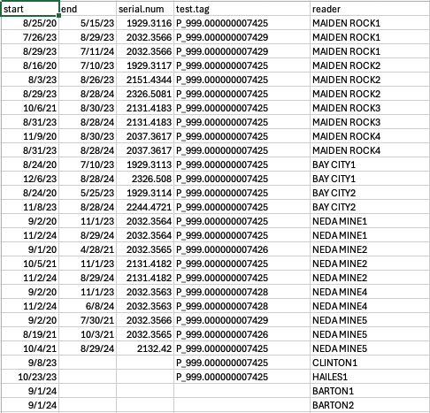

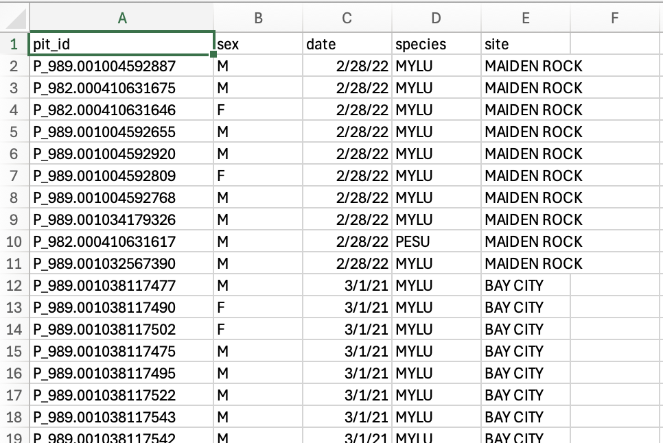

### 3.2.1 first, prepare your map1 file that contains reader information

‘format_map1’ requires 4 arguments:

- **path.csv**, the file path where the map1 file that contains the dates, serial numbers, and locations (e.g., site names) of the readers
- **date1**, column name of the deployment dates (or start dates) of the readers at the respective site
- **date2**, column name of the last date the reader was deployed at the respective site
- **date.format**, the format of the dates in the map1 file. See ‘as.Date’ function in base R for acceptable formats.

This function will default to the current date if the reader is still active at a site

```r
# read in first map file (m1) and auto format with format_map1 function
# m1 <- format_map1(path.csv = "/Users/mkailing/Dropbox/Kailing_Projects/pitmastr/dummy_MW/sn_map.csv",
#                   date1 = start,
#                   date2 = end,
#                   date.format = "%m/%d/%y")

#check dataframe
# head(m1); tail(m1)
```

### 3.2.2 second, prepare your map2 file that contains biological data associated with individuals

- **path.csv**, the file path including the name of the map2 file that contains the biological data
- **date1**, column name of the sampling dates (or start dates) of the readers at the respective site
- **date.format**, the format of the dates in the map1 file. See ‘as.Date’ function in base R for acceptable formats.
- **id.col**, column name that stores pit tag IDs

```r
# read in second map file (m2) and auto format with format_map2 function
# m2 <- format_m2("~/Dropbox/MIDWEST_WNS/DATA/midwest_master.csv",
#                 date1 = date,
#                 date.format = "%m/%d/%y",
#                 id.col = pit_id)

# check dataframe
# head(m2); tail(m2)
```

# 4 Data assembly

The first family of data functions within *pitmastr* are used to wrangle data stored in PIT tag files. The primary data assembly function (‘workhorse’) will search the user specified directory (path) to find all files output by readers, extract the detections from those files and serial numbers of readers, and assemble them in a master dataframe that can be exported or manipulated subsequently. Objects returned from any of the assembly functions will have shared structure, so they can be combined easily using ‘rbind’ in base R.

## 4.1 Assemble data…

### 4.1.1 with **‘workhorse’**

The ‘workhorse’ function was built to search all folders within the directory for each of the file types that can be exported by the readers.

‘workhorse’ requires three arguments:

- **path**, the directory containing folders that store files downloaded from readers
- **string**, the shared prefix/suffix appended to all parent folders
- **map.file1**, the name of an object created using ‘format_map1’

and a fourth argument is optional:

- **remove.dup**, specify whether duplicated detections should be dropped from master dataframe once assembled (i.e., if one row is an exact match to another).
  - This argument defaults to “N”, such that all rows will be retained even if exact matches exist.
  - In most instances, duplicated rows are an artifact of accidentally duplicated data; ‘remove.dup=“Y”’ is strongly suggested.

In our example dataset, the highest folders are the primary site names. Within them, the *parent folders* contain the prefix “LOGGER_”, which is the pattern we call to the function indicating which folders to search for files containing detections from readers. The path up to the parent folder name will be included as a column in the returned object.

```r
# mastr_pit <- workhorse(directory = "/Users/mkailing/Dropbox/Kailing_Projects/pitmastr/dummy_MW",
#                        #map.file1 = m1,
#                        string = "LOGGER_")

## -------- OR

# mastr_pit <- workhorse(directory = "/Users/mkailing/Dropbox/Kailing_Projects/pitmastr/dummy_MW",
#                        string = "LOGGER_",
#                        remove.dup = "Y") #drops rows that have exact match with previous row (keeps single detection)
```

### 4.1.2 with **‘extract’**

The ‘extract_’ functions may be beneficial for users that prefer to create a smaller object of detections from one reader/one file type. If desired, these objects can eventually be merged to one large dataframe using base R’s ‘rbind’ function.

‘extract’ requires two arguments:

- **path**, the folder containing files downloaded from reader
- **filetype**, the extension for the type of file storing detections from the reader

```r
#df2 <- extract_txt(path = "/Users/mkailing/Dropbox/Kailing_Projects/pitmastr/test_MW/pitmastr_test",
#               filetype = ".txt")
```

## 4.2 Link individuals’ metrics to PIT detections using ‘integrate_ids’

The ‘integrate_ids’ function allows users to combine metadata on individuals to detections.

```r
# working_pit <- integrate_ids(mastr_pit, m2,
#                          joiner = 'pit_id',
#                          drop.tt = "Y")

## ------------- OR

# working_pit <- integrate_ids(mastr_pit, m2,
#                          joiner = 'pit_id',
#                          drop.tt = "N")
```

# 5 Data manipulation

This family of functions will create objects that users can use in simple statistical models and survival analyses.

- **x**, the df containing detections and desired grouping variables. In our example, we use the object returned from ‘integrate_ids’
- **obs.groups**, a list of column names by which the user wants data to be structured and summarized
- **obs.units**, the time unit by which to summarize observations
- **date.colname**, column name for date to summarize by

```r
# cmpr_ids_weeks <- compress_ids_date(x = working_pit,
#                                     obs.groups =  c(pit_id, sex, site.detected),
#                                     obs.unit = "weeks", date.colname = date)

## ------- OR

# cmpr_ids_months <- compress_ids_date(x = working_pit,
#                                      obs.groups = c(pit_id, sex, site.detected),
#                                      obs.unit = "months", date.colname = date)
```

# 6 Check status of readers

These functions are to evaluate the consistency (or identify gaps) in system operation and to create survival object (such that days when systems are running are considered a ‘sample event’).

- **x**, name of the object containing all detections (e.g., objects returned from the ‘workhorse’ function)
- **y**, name of the map 1 file or (e.g. objects returned from format_map1) or vector that contains the list of test tag IDs
- **site.col**, site (i.e., reader) column name in x. This allows user to evaluate coverage of each reader
- **min.reads**, minimum number of test tag fires needed in a day for a system to be considered ‘operating’. The value defaults to 2.

```r
# system_ops <- readr_check(x = mastr_pit, #if file is not stored in working directory, full file path will be required
#                            y = m1,
#                            min.reads = 3)
```

```r
# plot_system_ops <- readr_viz(df = system_ops,
#                               site.col = path)
```

# 7 Explore data using Shiny plots